# Associations between RBP expression and miRNA activity

# 9 Identify interactions for which the direction of correlation is in agreement with the predicted type of interaction (activating / inhibitory) in at least 70% of TCGA cancers

```r
length(unique(corr_table$interaction))
```

```
## [1] 19
```

```r
sign_consistent <- corr_table %>%
  group_by(interaction, RBP, miRNA, sign) %>%
  summarise(
    prop_agree = mean(ifelse(sign == "+", r > 0, r < 0), na.rm = TRUE),
    n_cancers = n(),
    .groups = "drop"
  ) %>%
  filter(prop_agree >= 0.70) %>%
  dplyr::select(interaction, RBP, miRNA, sign)
sign_consistent
```

```
## # A tibble: 12 × 4
##    interaction         RBP     miRNA      sign
##    <chr>               <chr>   <chr>      <chr>
##  1 DDX55 - miR-29-3p   DDX55   miR-29-3p  -
##  2 FAM120A - miR-29-3p FAM120A miR-29-3p  +
##  3 FMR1 - miR-296-3p   FMR1    miR-296-3p +
##  4 IGF2BP2 - miR-17-5p IGF2BP2 miR-17-5p  +
##  5 MSI2 - miR-17-5p    MSI2    miR-17-5p  +
##  6 PABPC4 - miR-17-5p  PABPC4  miR-17-5p  +
##  7 PTBP1 - miR-29-3p   PTBP1   miR-29-3p  -
##  8 RPLP0 - miR-29-3p   RPLP0   miR-29-3p  -
##  9 SERBP1 - miR-133-3p SERBP1  miR-133-3p -
## 10 SF1 - miR-199-5p    SF1     miR-199-5p -
## 11 SUPV3L1 - miR-17-5p SUPV3L1 miR-17-5p  +
## 12 SUPV3L1 - miR-19-3p SUPV3L1 miR-19-3p  +
```

```r
nrow(sign_consistent)
```

```
## [1] 12
```

```r
write.csv(sign_consistent, here("TCGA", "output", "supplementary_tables", "interactions_RBPKD_ENCODEcellsTissues_TCGA.csv"))
```

# 10 Example scatter plot for SUPV3L1-miR-19 in BRCA

Helper function to make a base R scatter plot of RBP expression vs. miRNA activity, for a given RBP, miRNA, and cancer type

```r
rbp_mirna_scatter <- function(rbp, mirna, cancer, save_pdf = FALSE, pdf_dir = here("TCGA", "output", "figures")) {
  expr_mat <- logRSEM_data[[cancer]]

  rbp_expr_vals <- as.numeric(expr_mat[rbp, ])
  names(rbp_expr_vals) <- colnames(expr_mat)

  mirna_data <- miR_act |>
    filter(cancer_type == cancer, miRNA == mirna)

  # Match samples between expression and miRNA activity data
  common_samples <- intersect(names(rbp_expr_vals), mirna_data$sample_name)

  rbp_matched <- rbp_expr_vals[common_samples]
  mirna_matched <- mirna_data$coefficient_log2[match(common_samples, mirna_data$sample_name)]

  corr <- cor.test(rbp_matched, mirna_matched)
  n_tumors <- sum(complete.cases(rbp_matched, mirna_matched))

  draw_plot <- function() {
    plot(rbp_matched, mirna_matched,
         pch = 19,
         cex = 0.35,
         main = cancer,
         xlab = paste0(rbp, " expression (log2RSEM)"),
         ylab = paste0(mirna, " activity"))
    abline(lm(mirna_matched ~ rbp_matched), col = "dodgerblue", lwd = 2)
    if (sign(corr$estimate) == 1){
      legend("bottomright",
             legend = paste0("r = ", round(corr$estimate, 3), "\np = ", signif(corr$p.value, 3), "\nn = ", n_tumors, " tumors"),
             bty = "n",
             inset = c(0, 0.1),
             cex = 0.9)
    } else {
      legend("topleft",
             legend = paste0("r = ", round(corr$estimate, 3), "\np = ", signif(corr$p.value, 3), "\nn = ", n_tumors, " tumors"),
             bty = "n",
             inset = c(-0.05, -0.05),
             cex = 0.9)
    }

  }

  draw_plot()

  if (save_pdf) {
    pdf_file <- file.path(pdf_dir, paste0("TCGA_", cancer, "_", rbp, "_", mirna, "_scatter.pdf"))
    pdf(pdf_file, width = 4, height = 4)
    draw_plot()
    dev.off()
  }

  invisible(corr)
}
```

Scatter plot for SUPV3L1 expression vs. miR-19-3p activity in BRCA

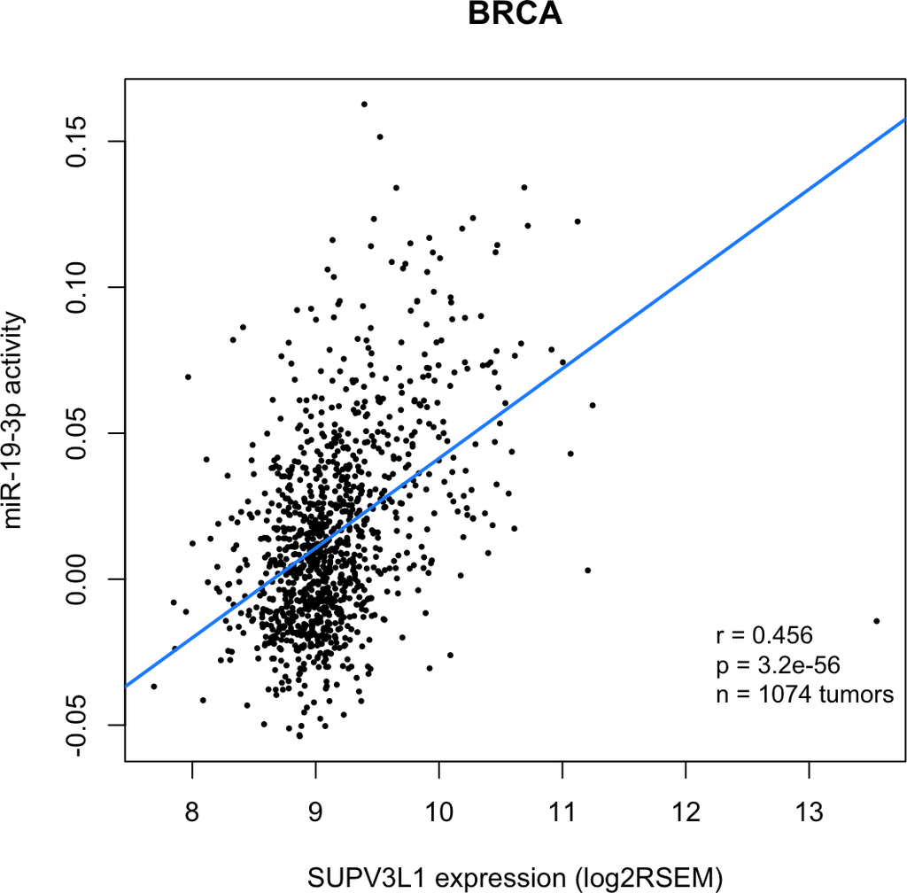

```r
rbp_mirna_scatter("SUPV3L1", "miR-19-3p", "BRCA", save_pdf = TRUE)
```

# 11 Example scatter plot for DDX55-miR-29 in STAD

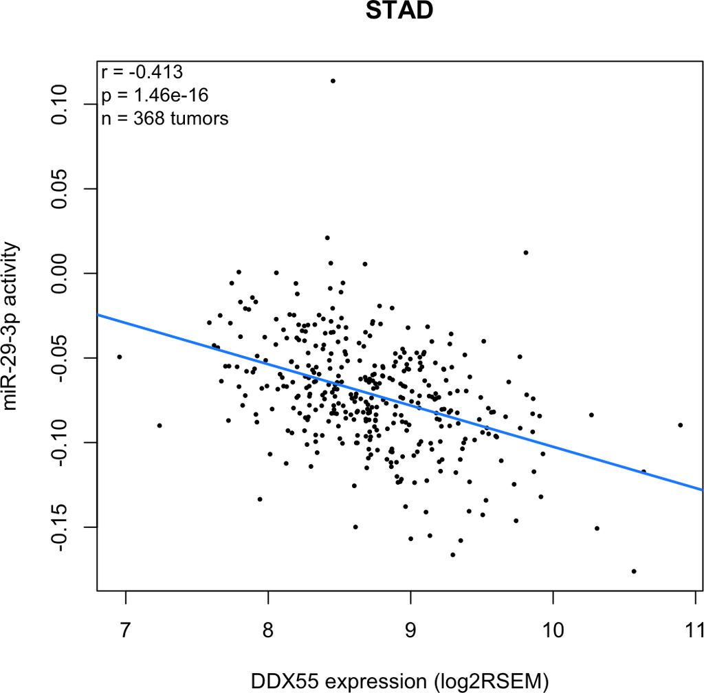

```r
rbp_mirna_scatter("DDX55", "miR-29-3p", "STAD", save_pdf = TRUE)
```

# 12 Example bar plot for DDX55 - miR-29-3p across cancers

Helper function to make bar plot of RBP vs. miRNA activity correlation across cancer types, for a given RBP-miRNA interaction

```r
rbp_mirna_barplot <- function(rbp, mirna, corr_data = corr_table,
                               sig_col = "pval", sig_threshold = 0.05,
                               bar_color = "#5B9BD5", ns_color = "grey70",
                               save_pdf = FALSE,
                               pdf_dir = here("TCGA", "output", "figures"),
                               width = 5.2, height = 4) {
  dat <- corr_data |>
    filter(RBP == rbp, miRNA == mirna) |>
    mutate(
      Significant = factor(
        ifelse(.data[[sig_col]] < sig_threshold, "p < 0.05", "NS"),
        levels = c("p < 0.05", "NS")
      )
    )

  # Order cancers by strength of correlation, matching the expected sign
  expected_sign <- unique(dat$sign)
  dat <- dat |>
    arrange(if (expected_sign == "-") r else dplyr::desc(r)) |>
    mutate(cancer = factor(cancer, levels = cancer))

  y_lab <- paste0(
    rbp, " expression vs ", mirna, " activity\n",
    "across tumors (Pearson r)"
  )

  p <- ggplot(dat, aes(x = cancer, y = r, fill = Significant)) +
    geom_col(colour = "black", linewidth = 0.3, width = 0.8) +
    scale_x_discrete(expand = expansion(add = 0.6)) +
    scale_fill_manual(values = c("p < 0.05" = bar_color, "NS" = ns_color), drop = FALSE) +
    labs(x = NULL, y = y_lab, fill = NULL) +
    theme_classic(base_size = 14) +
    theme(
      axis.text.x = element_text(angle = 90, hjust = 1, vjust = 0.5, colour = "black"),
      axis.text.y = element_text(colour = "black"),
      axis.title.y = element_text(size = 13),
      axis.line = element_line(linewidth = 0.4),
      axis.ticks = element_line(linewidth = 0.4),
      legend.position = if (expected_sign == "+") c(0.98, 0.98) else c(0.98, 0.02),
      legend.justification = if (expected_sign == "+") c(1, 1) else c(1, 0),
      legend.background = element_rect(colour = "black", linewidth = 0.3),
      legend.margin = margin(4, 6, 4, 6),
      plot.margin = margin(10, 10, 10, 10)
    )

  print(p)

  if (save_pdf) {
    pdf_file <- file.path(pdf_dir, paste0("TCGA_", rbp, "_", mirna, "_barplot.pdf"))
    ggsave(pdf_file, plot = p, width = width, height = height)
  }

  invisible(p)
}
```

# 13 Bar plot for DDX55 expression vs. miR-29-3p activity correlation across cancers

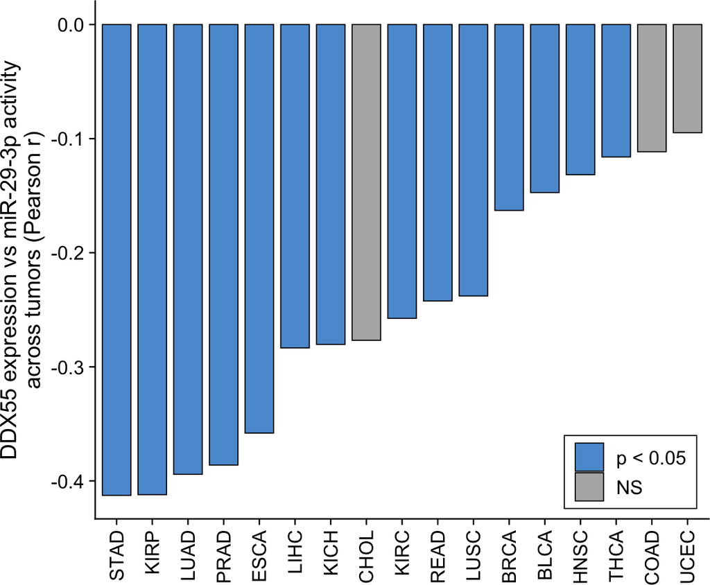

```r
rbp_mirna_barplot("DDX55", "miR-29-3p", save_pdf = TRUE)
```

# 14 Bar plot for PTBP1 expression vs. miR-29-3p activity

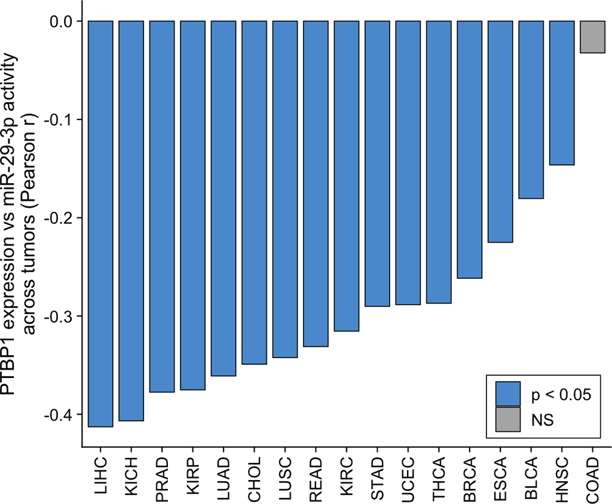

```r
rbp_mirna_barplot("PTBP1", "miR-29-3p", save_pdf = TRUE)
```

# 15 Bar plot for RPLP0 expression vs. miR-29-3p activity

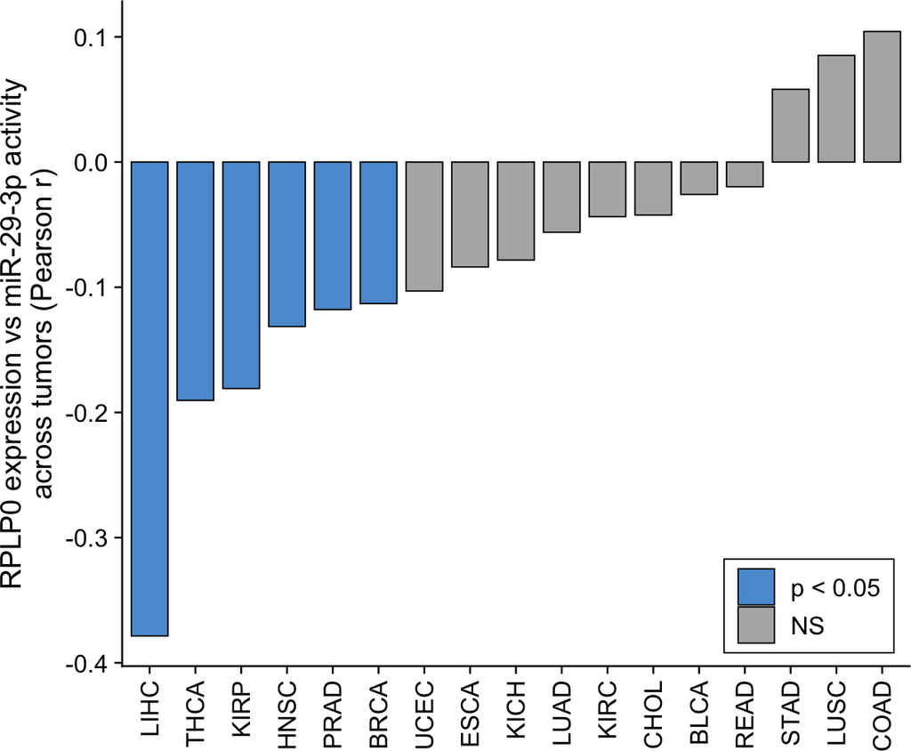

```r
rbp_mirna_barplot("RPLP0", "miR-29-3p", save_pdf = TRUE)
```

# 16 Bar plot for FAM120A expression vs. miR-29-3p activity

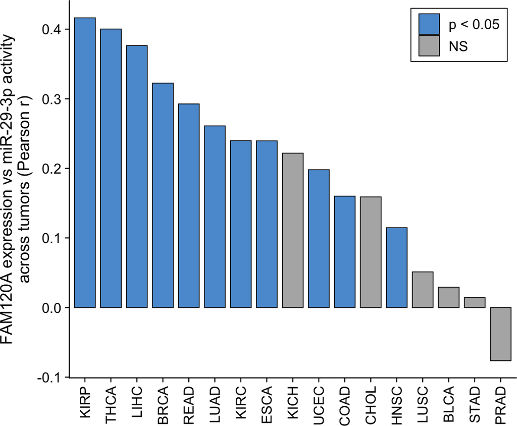

```r
rbp_mirna_barplot("FAM120A", "miR-29-3p", save_pdf = TRUE)
```

# 17 Correction of associations for tumor purity

Essentially the same analysis as above, but with an added correction for tumor purity, by computing partial correlations between RBP expression and miRNA activity while controlling for tumor purity as a covariate.

## 17.1 Load tumor purity estimates

```r
purity_files <- list.files(here("data"), pattern = "^purity_.*\\.txt$", full.names = TRUE)

purity_data <- purity_files |>
  setNames(str_extract(basename(purity_files), "(?<=purity_)[A-Z]+(?=\\.txt)")) |>
  lapply(function(f) {
    dat <- read.delim(f, stringsAsFactors = FALSE)
    # Keep only primary tumor, vial A samples (-01A-)
    dat <- dat[grepl("-01A-", dat$SampleName), ]
    dat$sample <- str_extract(dat$SampleName, "^TCGA-[^-]+-[^-]+-01") |>
      str_replace_all("-", ".")
    dat[, c("sample", "Purity")]
  })

head(purity_data[["UCEC"]])
```

```
##            sample Purity
## 1 TCGA.A5.A1OH.01 0.8731
## 2 TCGA.A5.A2K2.01 0.9720
## 3 TCGA.A5.A2K3.01 0.3757
## 4 TCGA.A5.A2K4.01 0.8182
## 5 TCGA.A5.A2K5.01 0.8341
## 6 TCGA.A5.A2K7.01 0.9288
```

## 17.2 Compute partial correlations controlling for tumor purity

```r
# Helper function to compute the partial correlation between the expression of a given RBP and the activity of a given miRNA, within a given cancer type, controlling for tumor purity
compute_partial_correlation_cancer <- function(rbp, mirna, cancer) {
  # Skip cancer types without a purity file
  if (!(cancer %in% names(purity_data))) {
    return(NULL)
  }

  expr_mat <- logRSEM_data[[cancer]]

  # Skip if the RBP is not present in this cancer's expression data
  if (!(rbp %in% rownames(expr_mat))) {
    return(NULL)
  }

  rbp_expr <- as.numeric(expr_mat[rbp, ])
  names(rbp_expr) <- colnames(expr_mat)

  mirna_data <- miR_act |>
    filter(cancer_type == cancer, miRNA == mirna)

  if (nrow(mirna_data) == 0) {
    return(NULL)
  }

  purity_cancer <- purity_data[[cancer]]

  # Match samples across expression, miRNA activity, and purity data
  common_samples <- Reduce(intersect, list(names(rbp_expr), mirna_data$sample_name, purity_cancer$sample))
  if (length(common_samples) < 4) {
    return(NULL)
  }

  rbp_matched <- rbp_expr[common_samples]
  mirna_matched <- mirna_data$coefficient_log2[match(common_samples, mirna_data$sample_name)]
  purity_matched <- purity_cancer$Purity[match(common_samples, purity_cancer$sample)]

  pcorr <- pcor.test(rbp_matched, mirna_matched, purity_matched)
  tibble(r = pcorr$estimate, pval = pcorr$p.value, n = pcorr$n)
}
```

```r
# Compute the purity-corrected partial correlations for every RBP-miRNA interaction, in every cancer type
corr_table_purity <- interactions |>
  dplyr::select(RBP, miRNA, sign) |>
  # Cross every interaction with every cancer type
  tidyr::crossing(cancer = cancer_types) |>
  mutate(
    interaction = paste(RBP, miRNA, sep = " - "),
    corr_data = pmap(list(RBP, miRNA, cancer), compute_partial_correlation_cancer)
  ) |>
  unnest(corr_data, keep_empty = TRUE) |>
  filter(!is.na(r)) |>
  mutate(
    padj = p.adjust(pval, method = "fdr"),
    signedlog10pvals = abs(log10(pval))
  ) |>
  dplyr::select(interaction, RBP, miRNA, sign, cancer, r, pval, padj, signedlog10pvals, n) |>
  as.data.frame()

head(corr_table_purity)
```

```
##         interaction  RBP      miRNA sign cancer            r       pval
## 1 AATF - miR-455-5p AATF miR-455-5p    -   BLCA -0.062759075 0.31247934
## 2 AATF - miR-455-5p AATF miR-455-5p    -   BRCA -0.028923574 0.44095450
## 3 AATF - miR-455-5p AATF miR-455-5p    -   COAD -0.008171843 0.89546785
## 4 AATF - miR-455-5p AATF miR-455-5p    -   HNSC  0.060315452 0.19226163
## 5 AATF - miR-455-5p AATF miR-455-5p    -   KICH  0.241984061 0.06482069
## 6 AATF - miR-455-5p AATF miR-455-5p    -   KIRC  0.002838790 0.96036207
##        padj signedlog10pvals   n
## 1 0.3958072        0.5051787 262
## 2 0.5331541        0.3556062 713
## 3 0.9402262        0.0479500 262
## 4 0.2701735        0.7161074 470
## 5 0.1126948        1.1882864  60
## 6 0.9713168        0.0175650 310
```

```r
nrow(corr_table_purity)
```

```
## [1] 266
```

## 17.3 Dotplot of purity-corrected correlations

```r
r_mat_purity <- corr_table_purity |>
  dplyr::select(interaction, cancer, r) |>
  pivot_wider(names_from = cancer, values_from = r) |>
  column_to_rownames("interaction") |>
  as.matrix()

row_clust_purity <- hclust(dist(r_mat_purity, method = "euclidean"), method = "complete")
col_clust_purity <- hclust(dist(t(r_mat_purity), method = "euclidean"), method = "complete")

interaction_levels_purity <- rownames(r_mat_purity)[row_clust_purity$order]
cancer_levels_purity <- colnames(r_mat_purity)[col_clust_purity$order]
```

Make the data table for the dotplot, clustered and converting saturated values

```r
dat_htmp_purity <- corr_table_purity |>
  transmute(
    Interactions = factor(interaction, levels = interaction_levels_purity),
    Cancers = factor(cancer, levels = cancer_levels_purity),
    `-log10(p-value)` = pmin(signedlog10pvals, pval_lim),
    `Pearson r` = pmax(pmin(r, coeff_lim), -coeff_lim),
    FDR = as.integer(padj < 0.05)
  )
```

Assign interaction labels colors according to each interaction’s expected sign

```r
sign_by_interaction_purity <- corr_table_purity |>
  distinct(interaction, sign) |>
  deframe()

colors_sign_purity <- ifelse(sign_by_interaction_purity[interaction_levels_purity] == "-", "blue", "red")
```

Draw the dotplot

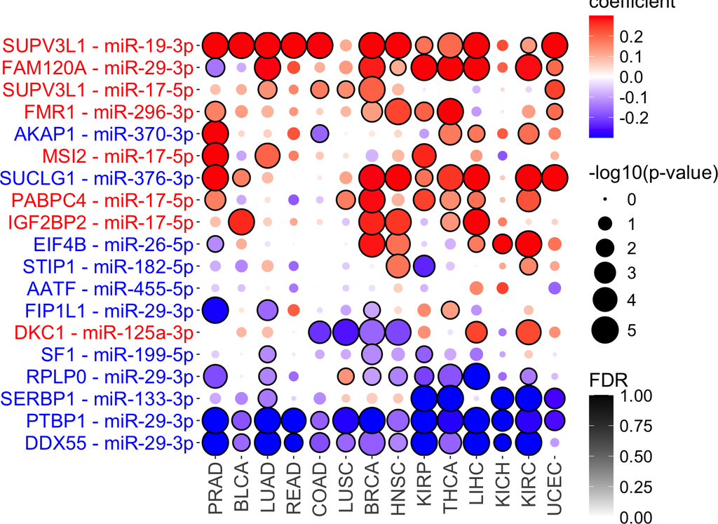

```r
dotplot_purity <- ggplot(dat_htmp_purity, aes(x = Cancers, y = Interactions)) +
  geom_point(aes(size = `-log10(p-value)`, fill = `Pearson r`, color = FDR),
             shape = 21, stroke = 1) +
  scale_fill_gradient2(name = "Partial correlation\ncoefficient", limits = c(-coeff_lim, coeff_lim), low = "blue", mid = "white", high = "red") +
  scale_colour_gradient(limits = c(0, 1), low = "white", high = "black") +
  scale_size("-log10(p-value)", range = c(0.1, 10), breaks = seq(0, pval_lim, 1), limits = c(0, pval_lim)) +
  guides(size = guide_legend(override.aes = list(fill = "black"))) +
  labs(x = "", y = "") +
  theme(
    axis.text.y = element_text(color = colors_sign_purity, size = 17),
    legend.key.size = unit(1.5, "lines"),
    text = element_text(size = 16),
    axis.text = element_text(size = 17),
    axis.text.x = element_text(angle = 90, size = 17, vjust = 0.5, hjust = 1),
    axis.title = element_text(size = 18),
    legend.title = element_text(size = 17),
    legend.text = element_text(size = 15),
    panel.background = element_rect(fill = "white", colour = "white"),
    plot.margin = unit(c(1, 1, 1, 1), "cm")
  )

dotplot_purity
```

```r
pdf(here("TCGA", "output", "figures", "TCGA_high_conf_ints_corrRBPexprMirAct_purityCorrected_dotplot.pdf"), width = 10, height = 8)
print(dotplot_purity)
dev.off()
```

## 17.4 Identify interactions consistent with the predicted direction in at least 70% of TCGA cancers, after purity correction

```r
length(unique(corr_table_purity$interaction))
```

```
## [1] 19
```

```r
sign_consistent_purity <- corr_table_purity %>%
  group_by(interaction, RBP, miRNA, sign) %>%
  summarise(
    prop_agree = mean(ifelse(sign == "+", r > 0, r < 0), na.rm = TRUE),
    n_cancers = n(),
    .groups = "drop"
  ) %>%
  filter(prop_agree >= 0.70) %>%
  dplyr::select(interaction, RBP, miRNA, sign)
sign_consistent_purity
```

```
## # A tibble: 12 × 4
##    interaction         RBP     miRNA      sign
##    <chr>               <chr>   <chr>      <chr>
##  1 DDX55 - miR-29-3p   DDX55   miR-29-3p  -
##  2 FAM120A - miR-29-3p FAM120A miR-29-3p  +
##  3 FMR1 - miR-296-3p   FMR1    miR-296-3p +
##  4 IGF2BP2 - miR-17-5p IGF2BP2 miR-17-5p  +
##  5 MSI2 - miR-17-5p    MSI2    miR-17-5p  +
##  6 PABPC4 - miR-17-5p  PABPC4  miR-17-5p  +
##  7 PTBP1 - miR-29-3p   PTBP1   miR-29-3p  -
##  8 RPLP0 - miR-29-3p   RPLP0   miR-29-3p  -
##  9 SERBP1 - miR-133-3p SERBP1  miR-133-3p -
## 10 SF1 - miR-199-5p    SF1     miR-199-5p -
## 11 SUPV3L1 - miR-17-5p SUPV3L1 miR-17-5p  +
## 12 SUPV3L1 - miR-19-3p SUPV3L1 miR-19-3p  +
```

```r
nrow(sign_consistent_purity)
```

```
## [1] 12
```

```r
write.csv(sign_consistent_purity, here("TCGA", "output", "supplementary_tables", "interactions_RBPKD_ENCODEcellsTissues_TCGA_purityCorrected.csv"))
```